# Homework 01

## Question 1 (Least squares and matrix calculations)

Set the random seed to 43201. Generate $n=100$ observations with $p=5$ predictors according to

$$x_{ij}\overset{\mathrm{iid}}{\sim}N(0,1),
\qquad
\varepsilon_i\overset{\mathrm{iid}}{\sim}N(0,0.7^2),$$

with all predictors and errors generated independently. Let

$$\mathbf X
=
\begin{bmatrix}
\mathbf 1 & \mathbf x_1 & \cdots & \mathbf x_5
\end{bmatrix},
\qquad
\boldsymbol\beta
=
(3,1.4,-0.9,0.7,0,1.1)^{\mathsf T},$$

and generate

$$\mathbf y=\mathbf X\boldsymbol\beta+\boldsymbol\varepsilon.$$

1. Generate the data and report the dimensions and rank of $\mathbf X$. Calculate the least-squares estimate $\widehat{\boldsymbol\beta}$ using a numerically stable least-squares routine, without explicitly calculating $(\mathbf X^{\mathsf T}\mathbf X)^{-1}$. Compare the estimates with the coefficients used to generate the data.

   ```r
   library(tidyverse)
   r.seed = 43201
   n = 100
   p = 5
   x1 = rnorm(n, 0, 1)
   x2 = rnorm(n, 0, 1)
   x3 = rnorm(n,0,1)
   x4 = rnorm(n,0,1)
   x5 = rnorm(n,0,1)
   e = rnorm(n,0,0.7^2)
   X = cbind(1,x1,x2,x3,x4,x5)
   betav = c(3,1.4,-0.9,0.7,0,1.1)
   beta = matrix(betav, nrow = 6, ncol = 1)
   y = X%*%beta + e
   ```

   Dimensions and Rank of X:

   100 rows, 6 columns. Full rank

   ```r
   dim(X)
   ```

   ```
   [1] 100   6
   ```

   ```r
   qr(X)$rank
   ```

   ```
   [1] 6
   ```

   Calculate $\hat\beta$ using least squares without $(X^TX)^{-1}$.

   ```r
   md = summary(lm(y ~ X))
   md
   ```

   ```
   Call:
   lm(formula = y ~ X)

   Residuals:
        Min       1Q   Median       3Q      Max
   -1.12821 -0.38901  0.00818  0.36063  1.01794

   Coefficients: (1 not defined because of singularities)
                Estimate Std. Error t value Pr(>|t|)
   (Intercept)  2.999463   0.054828  54.707   <2e-16 ***
   X                  NA         NA      NA       NA
   Xx1          1.477186   0.045515  32.455   <2e-16 ***
   Xx2         -0.930567   0.053050 -17.541   <2e-16 ***
   Xx3          0.614359   0.054165  11.342   <2e-16 ***
   Xx4         -0.005155   0.051183  -0.101     0.92
   Xx5          1.144706   0.052183  21.937   <2e-16 ***
   ---
   Signif. codes:  0 '***' 0.001 '**' 0.01 '*' 0.05 '.' 0.1 ' ' 1

   Residual standard error: 0.4923 on 94 degrees of freedom
   Multiple R-squared:  0.9657,    Adjusted R-squared:  0.9638
   F-statistic: 528.9 on 5 and 94 DF,  p-value: < 2.2e-16
   ```

   ```r
   betahat = coef(md)[1:6]
   ```

2. Calculate the fitted values, the residual vector $\mathbf r=\mathbf y-\mathbf X\widehat{\boldsymbol\beta}$, and the training root mean squared error

$$\operatorname{RMSE}
=
\left(
\frac{1}{n}\sum_{i=1}^{n}r_i^2
\right)^{1/2}.$$

Fitted Values:

```r
yhat = X %*% betahat
```

Residual Vector

```r
resids = y - yhat
```

RMSE

```r
sqrt(sum(resids^2)*(1/n))
```

```
[1] 0.4772787
```

3. Report $\lVert\mathbf X^{\mathsf T}\mathbf r\rVert_\infty$. Explain why this value should be close to zero and what it tells us about the residual vector.

   (Wolfram Alpha: Maximum Absolute Row Sum Norm)

```r
val = t(X)%*%resids
norm(val, type = "I")
```

```
[1] 1.111888e-13
```

I learned that we are looking at the correlation between the matrix and the residuals. We would not want this value to be high because the residuals should be random without a pattern or association with our X matrix. This also means that the residuals vector is good for our use case and using OLS worked out.

## Question 2 (Gaussian likelihood for linear regression)

Continue with the data from Question 1. Suppose

$$\mathbf Y\mid\mathbf X
\sim
N_n\left(\mathbf X\boldsymbol\beta,\sigma^2\mathbf I_n\right).$$

The log-likelihood, including the constant term, is

$$\ell(\boldsymbol\beta,\sigma^2)
=
-\frac{n}{2}\log(2\pi\sigma^2)
-\frac{1}{2\sigma^2}
(\mathbf y-\mathbf X\boldsymbol\beta)^{\mathsf T}
(\mathbf y-\mathbf X\boldsymbol\beta).$$

1. For fixed $\sigma^2$, explain why maximizing $\ell(\boldsymbol\beta,\sigma^2)$ over $\boldsymbol\beta$ is equivalent to minimizing the residual sum of squares. What does this imply about the maximum-likelihood estimate of $\boldsymbol\beta$?

   If we fixed $\sigma^2$, then everything in the log-likelihood equation would become a constant except for $(y-X\beta)^T(y-X\beta)$ which is the same as minimizing the residual sum of squares. This implies that the MLE of beta is equal to the minimization of the RSS.
2. For fixed $\boldsymbol\beta$, differentiate the log-likelihood with respect to $\sigma^2$ and derive its maximum-likelihood estimate. Calculate this estimate at $\widehat{\boldsymbol\beta}$ and compare it with the unbiased estimate of $\sigma^2$. Explain why the two denominators differ.

   MLE: $\sigma^2 = \frac{-2\pi}{n}(y-X\beta)^T(y-X\beta)$

   Should be not negative, no $2\pi$.

   $\sigma^2 = \frac{1}{n}(y-X\beta)^T(y-X\beta)$

   ```r
   sigmahatc = 1/n*t((y-X%*%betahat))%*%(y-X%*%betahat)
   sigmahatc
   ```

   ```
            [,1]
   [1,] 0.227795
   ```

3. Let

$$\mathbf e_{x_2}=(0,0,1,0,0,0)^{\mathsf T}.$$

Using the variance estimate from part b, plot

$$\ell\left(
\widehat{\boldsymbol\beta}+t\mathbf e_{x_2},
\widehat{\sigma}_{\mathrm{MLE}}^2
\right)$$

over a grid of $t$ values from $-1.25$ to $1.25$. State where the maximum occurs and explain why this agrees with the least-squares result.

```r
evalues = c(0,0,1,0,0,0)
ex2 = matrix(evalues, nrow = 6, ncol = 1)
ts = seq(-1.25, 1.25, by = 0.25)
ts
```

```
 [1] -1.25 -1.00 -0.75 -0.50 -0.25  0.00  0.25  0.50  0.75  1.00  1.25
```

$\ell(\boldsymbol\beta,\sigma^2)= -\frac{n}{2}\log(2\pi\sigma^2) -\frac{1}{2\sigma^2} (\mathbf y-\mathbf X\boldsymbol\beta)^{\mathsf T} (\mathbf y-\mathbf X\boldsymbol\beta).$

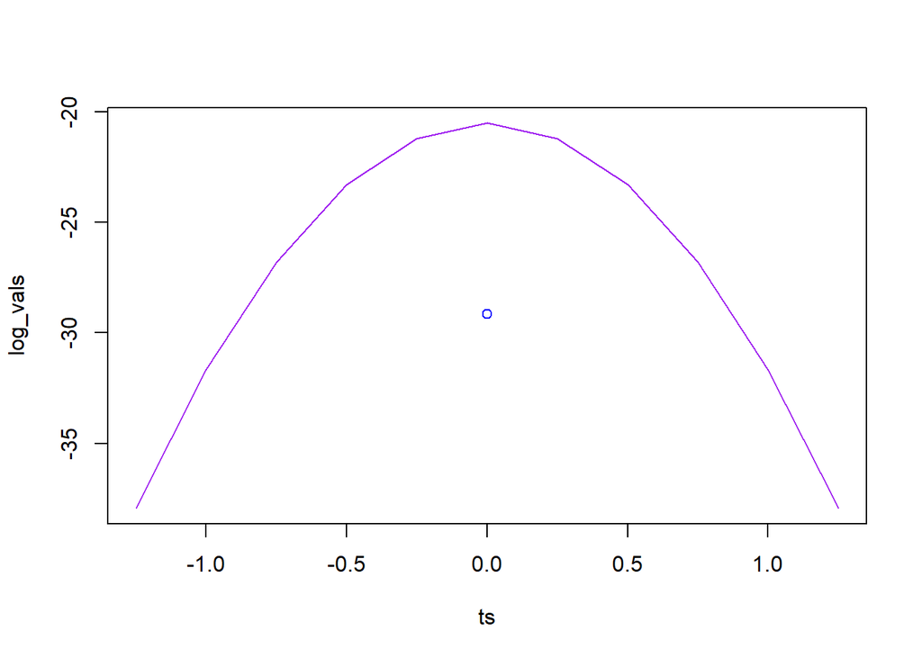

```r
logf = function(x){
  betat = betahat + x*ex2
  return(-n/2*log(2*pi*sigmahatc)-(1/2*sigmahatc)*t((y-X%*%betat))%*%(y-X%*%betat))
}

log_vals = sapply(ts, logf)

plot(ts, log_vals,type = "l",col = "purple")
points(0, -29.15831, col = "blue")
```

## Question 3 (Starting values in nonconvex optimization)

Consider the function

$$f(x)=\exp(1.5x)-3(x+6)^2-0.05x^3,$$

with derivative

$$f'(x)=1.5\exp(1.5x)-6(x+6)-0.15x^2.$$

1. Plot $f(x)$ over the interval $[-40,7]$. Based on the plot, describe the important features of the objective function that may affect numerical optimization.

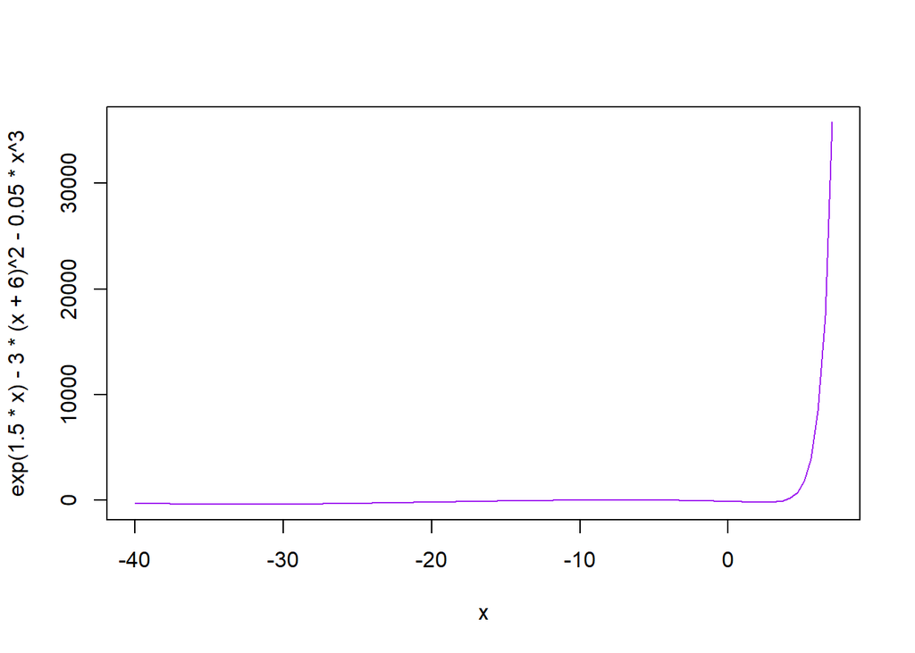

   ```r
   eq = function(x){
     return(exp(1.5*x)-3*(x+6)^2-0.05*x^3)
   }
   curve(exp(1.5*x)-3*(x+6)^2-0.05*x^3, from = -40, to = 7, col = "purple")
   ```

   Numerical Optimization: finding the max/min of a problem

   This graph would be hard to numerically optimize because it seems to approach 0 as x goes toward negative infinity and approaches infinity as x goes toward positive infinity, so it will be hard to find a set maximum.
2. Use BFGS to minimize $f(x)$ twice, starting at $x^{(0)}=-15$ and $x^{(0)}=0$. Supply $f'(x)$ to the optimizer. For each run, report the final value of $x$, the final objective value, $|f'(x)|$, and whether the optimizer reported convergence.

   BFGS: Broyden-Fletcher-Goldfarb-Shanno algorithm. This will allow us to find the minimum of a (twice-differentiable) convex function. (towardsdatascience)

   ```r
   deri = function(x){
     return(1.5*exp(1.5*x)-6*(x+6)-0.15*x^2)
   }
   run1 = optim(par = -15, fn = eq, gr = deri, method = "BFGS")
   run2 = optim(par = 0, fn = eq, gr = deri, method = "BFGS")
   ```

   Run 1: Learning how to interpret

   par: estimated minimum of x

   value: f(x) evaluated at the par value like f(-32)

   convergence: 0 means yay it did!

   counts: how many times it had to calculate

   message: no warnings if NULL

   ```r
   run1
   ```

   ```
   $par
   [1] -32.64911

   $value
   [1] -390.3858

   $counts
   function gradient
         15        6

   $convergence
   [1] 0

   $message
   NULL
   ```

   Final Value of X: -32.65

   Convergence: yes

   ```r
   deri(-32.64911)
   ```

   ```
   [1] 2.431185e-06
   ```

   Run 2:

   ```r
   run2
   ```

   ```
   $par
   [1] 2.349967

   $value
   [1] -175.8626

   $counts
   function gradient
         22        6

   $convergence
   [1] 0

   $message
   NULL
   ```

   Final Value of X: 2.35

   ```r
   deri(2.35)
   ```

   ```
   [1] 0.002285424
   ```

   Convergence: yes
3. Explain why the two runs can converge to different answers. Which run gives the lower objective value? What additional evidence would be needed before claiming that this point is the global minimum?

   The two runs converged to different answers because of their different starting values. We can see from the graph that as x decreases, y approaches 0, so changing how small x is would affect what the global minimum is. The lower objective value was from the first run, starting at -15. We would have to run it from a smaller value like -30 and see if we get the same value as -15. This would determine if -15 has the global minimum just because it is smaller than x = 0 or if it really was the minimum.

## Question 4 (Nearly collinear predictors)

Continue with $\mathbf X$ and $\mathbf y$ from Question 1. Set the random seed to 43202 and generate

$$u_i\overset{\mathrm{iid}}{\sim}N(0,1),
\qquad i=1,\ldots,n.$$

```r
r.seed = 43202
u = rnorm(n,0,1)
```

Define

$$\mathbf x_6=\mathbf x_1+10^{-4}\mathbf u,
\qquad
\mathbf X_+
=
\begin{bmatrix}
\mathbf X & \mathbf x_6
\end{bmatrix},$$

and let

$$\mathbf y^\star=\mathbf y+10^{-3}\mathbf u.$$

```r
x6 = x1 + (10^-4)*u
Xplus = cbind(X, x6)
ystar = y + (10^-3)*u
```

Use a numerically stable least-squares routine throughout.

1. Fit $\mathbf y$ using $\mathbf X$ and $\mathbf X_+$. For each design matrix, report the condition number and training RMSE. For the augmented fit, also report the coefficients of $\mathbf x_1$ and $\mathbf x_6$.

```r
lm(y ~ X)
```

```
Call:
lm(formula = y ~ X)

Coefficients:
(Intercept)            X          Xx1          Xx2          Xx3          Xx4
   2.999463           NA     1.477186    -0.930567     0.614359    -0.005155
        Xx5
   1.144706
```

```r
summary(lm(y ~ Xplus))$coeff
```

```
                 Estimate   Std. Error      t value     Pr(>|t|)
(Intercept)  3.005391e+00   0.05496258  54.68067568 1.661054e-72
Xplusx1      5.552613e+02 476.41797220   1.16549187 2.468005e-01
Xplusx2     -9.305127e-01   0.05295087 -17.57313262 2.627669e-31
Xplusx3      6.133299e-01   0.05407099  11.34304940 3.097179e-19
Xplusx4     -2.243014e-03   0.05114891  -0.04385264 9.651159e-01
Xplusx5      1.147902e+00   0.05215789  22.00820443 1.204885e-38
Xplusx6     -5.537808e+02 476.41515843  -1.16239127 2.480508e-01
```

Condition Number for X

Condition Numbers: Cannot be smaller than one, but the smaller the better.

```r
kappa(X)
```

```
[1] 2.664189
```

RMSE for X

```r
# Taken from question 1
sqrt(sum(resids^2)*(1/n))
```

```
[1] 0.4772787
```

Condition Number for Xplus

```r
kappa(Xplus)
```

```
[1] 36673.17
```

RMSE for Xplus

```r
betahatplus = summary(lm(y ~ Xplus))$coeff[1:7]
yhatplus = Xplus %*% betahatplus
residsplus = y - yhatplus
sqrt(sum(residsplus^2)*(1/n))
```

```
[1] 0.473849
```

2. Fit $\mathbf y^\star$ using $\mathbf X_+$. Report the changes in the coefficients of $\mathbf x_1$ and $\mathbf x_6$. Compare the two fitted-value vectors using their root mean squared difference and maximum absolute difference.

   ```r
   summary(lm(ystar ~ Xplus))$coeff
   ```

   ```
                    Estimate   Std. Error      t value     Pr(>|t|)
   (Intercept)  3.005391e+00   0.05496258  54.68067568 1.661054e-72
   Xplusx1      5.452613e+02 476.41797220   1.14450190 2.553526e-01
   Xplusx2     -9.305127e-01   0.05295087 -17.57313262 2.627669e-31
   Xplusx3      6.133299e-01   0.05407099  11.34304940 3.097179e-19
   Xplusx4     -2.243014e-03   0.05114891  -0.04385264 9.651159e-01
   Xplusx5      1.147902e+00   0.05215789  22.00820443 1.204885e-38
   Xplusx6     -5.437808e+02 476.41515843  -1.14140117 2.566335e-01
   ```

   ```r
   beta_star = summary(lm(ystar ~ Xplus))$coeff[1:7]
   yfitstar = Xplus %*% betahatplus
   resids_star = ystar - yfitstar
   sqrt(sum(resids_star^2)*(1/n))
   ```

   ```
   [1] 0.4738501
   ```

   Maximum absolute difference - subtract max & min values. For regular y:

   ```r
   yma = max(yhatplus)
   ymi = min(yhatplus)
   yma - ymi
   ```

   ```
   [1] 13.11421
   ```

   For $y^*$:

   ```r
   ysma = max(yfitstar)
   ysmi = min(yfitstar)
   ysma-ysmi
   ```

   ```
   [1] 13.11421
   ```

   The two values of the maximum absolute differences are the same.
3. Use the identity

$$\mathbf y^\star-\mathbf y
=
10(\mathbf x_6-\mathbf x_1)$$

to explain why the fitted values change very little while the two coefficients change substantially. What does this example suggest about interpreting separate effects for nearly collinear predictors?

If $y^*$ can be determine by a simple transformation of y ($y^* = y + 10(x_6 -x_1)$), then it makes sense that the coefficients are also changed by a transformation. However, the RMSE remains similar because you’re not explaining anything new by adding $x_6$. If predictors are nearly collinear, than their effects should be interpreted cautiously since they are providing similar information to the model. It would be better if collinearity was reduced and maybe just one of the predictors was kept.

## Question 5 (Data preparation and summary statistics)

The file `data/data-manipulation.csv` is a small constructed data table containing an observation identifier, a group label, two numeric predictors, and a response. Some response values are missing. For analyses involving the response, use only observations with a recorded response. Do not replace a missing response with zero or a group mean.

1. Read the data and report its dimensions, column types, number of duplicated identifiers, and number of missing values in each column. Create an analysis table containing only observations with a recorded response, and define

$$\texttt{feature\_sum}=\texttt{x1}+\texttt{x2}.$$

```r
library(tidyverse)
df = read.csv("C:/Users/sophi/OneDrive/stat432-fall2026/homework/data-manipulation.csv")
```

```r
head(df)
```

```
  observation_id group  x1  x2 response
1         obs-01     A 1.2 2.0     5.36
2         obs-02     A 2.4 1.1     6.18
3         obs-03     A 0.8 2.8     4.62
4         obs-04     A 3.1 1.5       NA
5         obs-05     A 2.0 2.2     5.52
6         obs-06     A 1.7 1.8     5.64
```

```r
dim(df)
```

```
[1] 24  5
```

```r
str(df)
```

```
'data.frame':   24 obs. of  5 variables:
 $ observation_id: chr  "obs-01" "obs-02" "obs-03" "obs-04" ...
 $ group         : chr  "A" "A" "A" "A" ...
 $ x1            : num  1.2 2.4 0.8 3.1 2 1.7 2.8 1 3.5 2.7 ...
 $ x2            : num  2 1.1 2.8 1.5 2.2 1.8 0.9 2.5 1.4 2.3 ...
 $ response      : num  5.36 6.18 4.62 NA 5.52 5.64 7.18 4.7 7.84 7.24 ...
```

Number of Distinct Identifiers: 24 (there were no duplicates in “observation_id”)

```r
dim(df %>%
  distinct(df$observation_id))[1]
```

```
[1] 24
```

The columns x1 and x2 have no NAs, but there are 3 in the ‘response’ column.

```r
df %>%
  filter(is.na(x1) | is.na(x2) | is.na(response))
```

```
  observation_id group  x1  x2 response
1         obs-04     A 3.1 1.5       NA
2         obs-11     B 4.1 1.0       NA
3         obs-20     C 3.9 2.4       NA
```

```r
fs_df = df %>%
  filter(observation_id != "obs-04") %>%
  filter(observation_id != "obs-11") %>%
  filter(observation_id != "obs-20") %>%
  mutate(feature_sum = x1 + x2)
fs_df = as.data.frame(fs_df)
fs_df
```

```
   observation_id group  x1  x2 response feature_sum
1          obs-01     A 1.2 2.0     5.36         3.2
2          obs-02     A 2.4 1.1     6.18         3.5
3          obs-03     A 0.8 2.8     4.62         3.6
4          obs-05     A 2.0 2.2     5.52         4.2
5          obs-06     A 1.7 1.8     5.64         3.5
6          obs-07     A 2.8 0.9     7.18         3.7
7          obs-08     A 1.0 2.5     4.70         3.5
8          obs-09     B 3.5 1.4     7.84         4.9
9          obs-10     B 2.7 2.3     7.24         5.0
10         obs-12     B 3.0 1.9     7.04         4.9
11         obs-13     B 2.2 2.7     6.58         4.9
12         obs-14     B 3.8 1.2     8.66         5.0
13         obs-15     B 2.5 2.1     6.86         4.6
14         obs-16     B 4.4 0.8     9.00         5.2
15         obs-17     C 5.0 1.7     8.32         6.7
16         obs-18     C 4.2 2.6     6.72         6.8
17         obs-19     C 5.5 1.3     8.58         6.8
18         obs-21     C 4.8 1.6     7.50         6.4
19         obs-22     C 5.9 0.7     9.24         6.6
20         obs-23     C 4.5 2.0     7.40         6.5
21         obs-24     C 5.2 1.1     8.22         6.3
```

2. For each group, report the number of observations, the mean response, and the mean of `feature_sum`. State clearly which observations these summaries describe.

```r
table = fs_df %>%
  summarize(total_observations = n(), mean_response = mean(response), mean_featuresum = mean(feature_sum), .by = "group")
table
```

```
  group total_observations mean_response mean_featuresum
1     A                  7      5.600000        3.600000
2     B                  7      7.602857        4.928571
3     C                  7      7.997143        6.585714
```

2. Sort the analysis table by response from largest to smallest and report the first three rows, including `observation_id`, `group`, `response`, and `feature_sum`. Add code checks verifying that the number of retained rows equals the number of nonmissing responses in the original data, that the analysis table has no missing response values, and that its identifiers are unique.

```r
fs_df %>%
  arrange(desc(response)) %>%
  head(n=3)
```

```
  observation_id group  x1  x2 response feature_sum
1         obs-22     C 5.9 0.7     9.24         6.6
2         obs-16     B 4.4 0.8     9.00         5.2
3         obs-14     B 3.8 1.2     8.66         5.0
```

```r
# checking the missing response values
check_df = fs_df %>%
  filter(is.na(x1)) %>%
  filter(is.na(x2)) %>%
  filter(is.na(response)) %>%
  filter(is.na(feature_sum)) %>%
  filter(is.na(observation_id))
if((dim(check_df)[1] == 0)[1]) {
  print("Yay! No missing response values!")
}
```

```
[1] "Yay! No missing response values!"
```

```r
# unique identifiers
rows = dim(fs_df)[1]
drows = dim(fs_df %>%
  distinct(observation_id))[1]
if(rows == drows){
  print("Let's go! Only unique identifiers!")
}
```

```
[1] "Let's go! Only unique identifiers!"
```

```r
# number of retained rows equals the number of nonmissing responses in the original data

shortdf = dim(df %>%
  filter(is.na(x1) | is.na(x2) | is.na(response)))[1]
subtract = (dim(df)[1])-shortdf

if(subtract == (dim(fs_df)[1])){
  print("Amazing! The retained rows equal the number of nonmissing responses in the original data.")
}
```

```
[1] "Amazing! The retained rows equal the number of nonmissing responses in the original data."
```

## Question 6 (Can 39 million Fitbit records represent US adults?)

[Patten et al. (2026)](https://doi.org/10.1038/s41591-026-04352-3) describe Fitbit data from 59,018 participants in the All of Us Research Program. The dataset spans 14 years and contains more than 39 million daily step records. Participants contributed data through one of two routes:

- Bring Your Own Device (BYOD): participants shared data from a Fitbit they already owned.
- Wearables Enhancing All of Us Research (WEAR): invited participants received a Fitbit at no cost.

In the general activity cohort, the BYOD and WEAR groups contained 32,035 and 22,474 participants, respectively. The BYOD value is listed first in each comparison below:

- 77.3% versus 55.1% reported being White;
- 6.1% versus 15.2% reported annual household income between $\$10{,}000$ and $\$25{,}000$; and
- median daily steps were 6,867 versus 5,797.

Suppose the target is the mean of the participant-specific average daily step counts among US adults during the study period, with each adult given equal weight. A researcher writes:

> “This dataset contains more than 39 million daily Fitbit records. Therefore, the average of all recorded step counts should provide an accurate estimate of mean daily activity among US adults.”
1. Are the 39 million daily records independent observations? What characteristics or behaviors could cause some participants to contribute more recorded days than others? Explain how averaging all recorded days would then weight participants unequally.
   1. The daily records are not entirely independent observations because they were contributed by the same people over a period of time. Perhaps the participants’ lifestyle could contribute to the number of recorded days they participated in. For example, if someone was very active then they might have enjoyed wearing their Fitbit and turning in high step counts, but if someone was more sedentary, then they might not want to submit that data. Similarly, someone with a very busy lifestyle or young kids might simply forget or be unable to wear the Fitbit. Also, their previous history of Fitbit use could influence this if they were used to wearing it already. Averaging all of the recorded days without taking into account possible differences between the groups would not be a very good idea. The average number of steps per day changes depending on so many factors, so to generalize someone like a 76 year old retired adult living in the country and a 18 year old college student in an urban area to have the same step count wouldn’t be the best depiction.
2. BYOD participants reported a median of 6,867 daily steps, compared with 5,797 among WEAR participants. Does this comparison show that already owning a Fitbit causes people to walk more? Explain your answer and give at least one plausible alternative explanation based on how participants entered the two groups.
   1. Not necessarily, we would need more information on the specific treatment imposed on the two groups. Were they predisposed to higher levels of exercise since they had gone out to buy a Fitbit? Do they have higher financial security to spend extra money on a Fitbit and spend their free time exercising? The two groups maybe could have been split based on people who needed to exercise more because of health concerns, so the treatment was imposed upon them. Or, maybe there are geographical differences.
3. A very large dataset can still produce a biased estimate of a population quantity when the people and observations entering the dataset are selected. Using this study, explain how selection of both participants and recorded days could make the observed data differ from the US adult population. Why might the naive average of all recorded daily step counts fail to estimate the stated target? You do not need to determine the direction of the bias.
   1. As we have been learning in my data science ethics class, it is challenging to argue that data is generalizable to a larger population than it was gathered from. Especially in this instance, we do not know how the people were gathered for this study - were they volunteers? Were they selected randomly from different ages, parts of the U.S., backgrounds, etc? If the diversity of the sample does not reflect the diversity of the United States, than the data likely would not reflect the true steps of the US adult population. Additionally, the average of all step counts would likely be biased due to what we learned about in my physical fitness class. When people first get a Fitbit, they are excited and you often have to exclude some of the initial data because they are stepping more than normal. This was also gathered over a very long time, so is it intended to be the average now when it was collected 14 years ago? There is more information we would need to know.

### Source

Patten, T., Preble, E. A., Master, H., et al. (2026). [The All of Us Research Program’s wearables dataset](https://doi.org/10.1038/s41591-026-04352-3). *Nature Medicine*, 32, 2302-2310.